Home > Archives > R语言文本挖掘实践

# R语言文本挖掘实践

Publish: March 26, 2015

# 文本挖掘实践

zengfan

2015年3月24日

## 使用R进行进行文本挖掘

tm包目前对于中文支持不是很好，我们使用该包进行英文挖掘莎士比亚的英文著作。

### 下载和预处理

```r
setwd("/Users/zengfan/Documents/myJob/myRlib/2015freelab")
#下载著作到文件夹中
TEXTFILE='word/word/pg100.txt'
if(!file.exists(TEXTFILE)){
  download.file('http://www.gutenberg.org/cache/epub/100/pg100.txt',destfile=TEXTFILE)}


#读取到R内存中
shakespeare=readLines(TEXTFILE)
length(shakespeare)
```

```
## [1] 124787
```

```r
head(shakespeare)
```

```
## [1] "The Project Gutenberg EBook of The Complete Works of William Shakespeare, by"
## [2] "William Shakespeare"
## [3] ""
## [4] "This eBook is for the use of anyone anywhere at no cost and with"
## [5] "almost no restrictions whatsoever.  You may copy it, give it away or"
## [6] "re-use it under the terms of the Project Gutenberg License included"
```

```r
tail(shakespeare)
```

```
## [1] "http://www.gutenberg.org/2/4/6/8/24689"
## [2] ""
## [3] "An alternative method of locating eBooks:"
## [4] "http://www.gutenberg.org/GUTINDEX.ALL"
## [5] ""
## [6] "*** END: FULL LICENSE ***"
```

```r
#使用txt文档编辑器查看，并去掉不需要的部分.
shakespeare=shakespeare[-(1:173)]
shakespeare=shakespeare[-(124195:length(shakespeare))]

#使用paste: Concatenate vectors after converting to character.
#查看有多少字
shakespeare<-paste(shakespeare,collapse=' ')

nchar(shakespeare)
```

```
## [1] 5436540
```

```r
#有一些重复出现的段落，
#<<THIS ELECTRONIC VERSION OF THE COMPLETE WORKS OF WILLIAM
#SHAKESPEARE IS COPYRIGHT 1990-1993 BY WORLD LIBRARY, INC., AND IS
#PROVIDED BY PROJECT GUTENBERG ETEXT OF ILLINOIS BENEDICTINE COLLEGE
#WITH PERMISSION.  ELECTRONIC AND MACHINE READABLE COPIES MAY BE
#DISTRIBUTED SO LONG AS SUCH COPIES (1) ARE FOR YOUR OR OTHERS
#PERSONAL USE ONLY, AND (2) ARE NOT DISTRIBUTED OR USED
#COMMERCIALLY.  PROHIBITED COMMERCIAL DISTRIBUTION INCLUDES BY ANY
#SERVICE THAT CHARGES FOR DOWNLOAD TIME OR FOR MEMBERSHIP.>>
#我们按照该段落，进行分割,使用strsplit()函数,该函数和paste相反
#strsplit(x, split, fixed = FALSE, perl = FALSE, useBytes = FALSE)

shakespeare=strsplit(shakespeare,split='<<[^>]*>>')[[1]]

length(shakespeare)
```

```
## [1] 218
```

```r
#grep:grep(value = FALSE) returns a vector of the indices of the elements of x that yielded a match (or not, for invert = TRUE. This will be an integer vector unless the input is a long vector, when it will be a double vector.

#还有一些段落是不重要的
#比如Dramatis Personae，我们也把它们删除
(dramatis.personae <- grep("Dramatis Personae", shakespeare, ignore.case = TRUE))
```

```
##  [1]   2   8  11  17  23  28  33  43  49  55  62  68  74  81  87  93  99
## [18] 105 111 117 122 126 134 140 146 152 158 164 170 176 182 188 194 200
## [35] 206 212
```

```r
shakespeare<-shakespeare[-dramatis.personae]
#crtl+L是清屏（mac）
```

## 进一步预处理

接下来将使用tm包进行分析

```r
library(tm)
#形成预料corpus
doc.vec<-VectorSource(shakespeare)
doc.corpus<-Corpus(doc.vec)

#summary(doc.corpus)
```

一些语义信息不是有用的，比如大小写，比如停词、比如数字和标点，接下来我们去掉这些信息。

```r
doc.corpus <- tm_map(doc.corpus, content_transformer(tolower))
doc.corpus <- tm_map(doc.corpus, removePunctuation)
doc.corpus <- tm_map(doc.corpus, removeNumbers)
doc.corpus <- tm_map(doc.corpus, removeWords, stopwords("english"))
```

接下来，我们把词干信息截取下来，比如把running,runs,run变为run

```r
library(SnowballC)
doc.corpus <- tm_map(doc.corpus, stemDocument)
```

上述操作增加了很多的空格，我们也一并删除掉

```r
doc.corpus<-tm_map(doc.corpus,stripWhitespace)
```

### TDM构建

如果上述操作没有错误的话，我们接下来将构建TDM（Term Document Matrix词矩阵），该词矩阵反映每个词的在文档中的频率。

```r
TDM<-TermDocumentMatrix(doc.corpus)
#该词矩阵的信息，比如空置率等
dim(TDM)
```

```
## [1] 18651   182
```

```r
inspect(TDM[1:10,1:10])
```

```
## <<TermDocumentMatrix (terms: 10, documents: 10)>>
## Non-/sparse entries: 1/99
## Sparsity           : 99%
## Maximal term length: 9
## Weighting          : term frequency (tf)
##
##            Docs
## Terms       1 2 3 4 5 6 7 8 9 10
##   aaron     0 0 0 0 0 0 0 0 0  0
##   abaissiez 0 0 0 0 0 0 0 0 0  0
##   abandon   0 0 0 0 0 0 0 0 0  0
##   abandond  0 1 0 0 0 0 0 0 0  0
##   abas      0 0 0 0 0 0 0 0 0  0
##   abashd    0 0 0 0 0 0 0 0 0  0
##   abat      0 0 0 0 0 0 0 0 0  0
##   abatfowl  0 0 0 0 0 0 0 0 0  0
##   abbess    0 0 0 0 0 0 0 0 0  0
##   abbey     0 0 0 0 0 0 0 0 0  0
```

### TDM探索

有了这个词矩阵，我们可以进行一些探索，比如：

莎士比亚在作品中最喜欢用的词是哪些？

```r
findFreqTerms(TDM,2000)
```

```
##  [1] "come"  "enter" "good"  "king"  "let"   "lord"  "love"  "make"
##  [9] "man"   "now"   "shall" "sir"   "thee"  "thi"   "thou"  "well"
## [17] "will"
```

与love高相关度的词有哪些？

```r
head(findAssocs(TDM,'love',0.8),10)
```

```
##        love
## beauti 0.83
## eye    0.80
```

```r
head(findAssocs(TDM,'man',0.5),5)
```

```
##        man
## good  0.59
## well  0.56
## civet 0.54
## come  0.54
## wise  0.54
```

通过观察TDM，我们发现很多词不是很常见，我们去掉这些很不常见的词。

```r
TDM.comon=removeSparseTerms(TDM,0.1)
dim(TDM.comon)
```

```
## [1]  71 182
```

我们发现，莎士比亚使用的这18651个词中，只有71个经常使用。

```r
inspect(TDM.comon[1:10,1:10])
```

```
## <<TermDocumentMatrix (terms: 10, documents: 10)>>
## Non-/sparse entries: 94/6
## Sparsity           : 6%
## Maximal term length: 6
## Weighting          : term frequency (tf)
##
##         Docs
## Terms     1 2  3  4  5  6  7  8 9 10
##   act     1 4  7  9  6  3  2 14 1  0
##   art    53 0  9  3  5  3  2 17 0  6
##   away   18 5  8  4  2 10  5 13 1  7
##   call   17 1  4  2  2  1  6 17 3  7
##   can    44 8 12  5 10  6 10 24 1  5
##   come   19 9 16 17 12 15 14 89 9 15
##   day    43 2  2  4  1  5  3 17 2  3
##   enter   0 7 12 11 10 10 14 87 4  6
##   exeunt  0 3  8  8  5  4  7 49 1  4
##   exit    0 6  8  5  6  5  3 31 3  2
```

TDM是按照稀疏矩阵的形式存储的,我们分析一下他们的大小，可以看出，当矩阵非常稀疏的时候，可以节省较大的空间。

```r
library(slam)
TDM.dense<-as.matrix(TDM.comon)
TDM.d<-as.matrix(TDM)
object.size(TDM.comon)
```

```
## 213616 bytes
```

```r
object.size(TDM.dense)
```

```
## 118256 bytes
```

```r
object.size(TDM)
```

```
## 4030176 bytes
```

```r
object.size(TDM.d)
```

```
## 28258600 bytes
```

## 可视化

下面我们将对该数据进行可视化

### 词云图

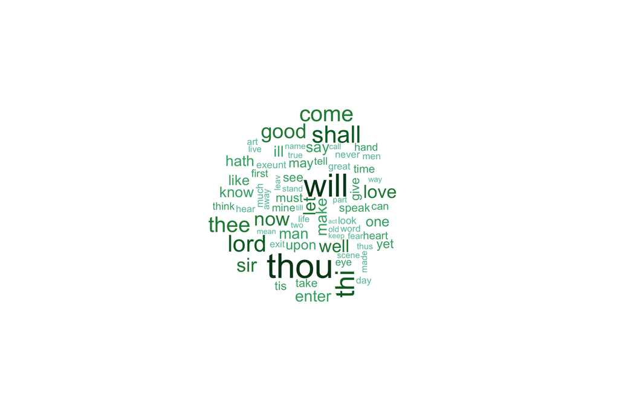

```r
library(wordcloud)
library(RColorBrewer)
palette<-brewer.pal(9,'BuGn')[-(1:4)]
wordcloud(rownames(TDM.dense),rowSums(TDM.dense),min.freq=1,color=palette)
```

## 热点图

我们使用ggplot2进行热点图（geom_til）的构建，首先我们使用melt函数将数据转化成ggplot支持的格式,我们使用melt函数将矩阵转换成数据框的格式（这里不需要指定variable.name，因为矩阵里面没有这个）。

```r
library(reshape2)
library(ggplot2)
TDM.dense=melt(TDM.dense,value.name='count',id.vars=c('Docs','Terms'))
```

然后，我们构建热力图，这里颜色越深表示频率越高，我们对count进行了log变换，这是为了减少count的大小悬殊，灰色的表示，没有这个词。

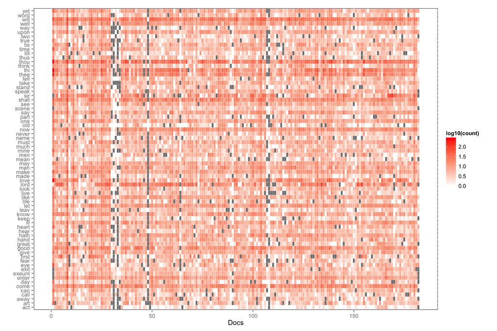

```r
ggplot(TDM.dense,aes(x=Docs,y=Terms,fill=log10(count)))+geom_tile(colour='white')+
  scale_fill_gradient(high='#FF0000',low="#FFFFFF")+ylab('')+theme(panel.background=NULL)+theme(axis.text.x=NULL,axis.ticks.x=NULL)
```

我们可以看到，love，lord等次在某些文档中非常普遍，而在某些文档中，却很少，而will这个词几乎个作品中都非常普遍。

## 总结

我们介绍了如何进行文本挖掘分析。

包括：

1. 准备文本材料(download.file)
2. 浏览文本并提取出需要分析的部分(readLines,parste)
3. 文本的整理和分段(strsplit,grep)
4. TM格式转换(VectorSOurce,Corpus)
5. 文本的预处理：去掉停词、词根、标点、数字(tm_map,content_transformer,removePunctuation,removeNumbers,removeWords,stopwords(‘English’),stemDocument,stripWhitespace)
6. 提取出TDM，词段落矩阵（稀疏矩阵）(TermDOcumentMatrix, removeSparseTerms)
7. 探索(findAssocs, findFreqTerms)
8. R格式转换(as.matrix)
9. 矩阵转换为数据框
10. 可视化（词云、热力图）

声明: 本文采用 [BY-NC-SA](http://creativecommons.org/licenses/by-nc-sa/3.0/) 授权。转载请注明转自: tegulia

« R语言应用简介与交互式分析基础

Ggvis交互式可视化介绍 »